# 6 Dealing with Categorical Variables - forcats

## `fct_recode`

*Example*: Find the relation between party affiliation and average hours of watching tv.

```r
gss_cat %>%
  group_by(partyid) %>%
  summarize(avg = mean(tvhours, na.rm = T))
```

```
## # A tibble: 10 × 2
##    partyid              avg
##    <fct>              <dbl>
##  1 No answer           3.22
##  2 Don't know          2
##  3 Other party         2.79
##  4 Strong republican   2.72
##  5 Not str republican  2.63
##  6 Ind,near rep        2.77
##  7 Independent         3.08
##  8 Ind,near dem        2.80
##  9 Not str democrat    3.04
## 10 Strong democrat     3.52
```

But it is still hard to answer the question because the `partyid` is not clearly defined. We need to recode factor `fct_recode()`

Let’s check the levels of `partyid` first:

```r
levels(factor(gss_cat$partyid))
```

```
##  [1] "No answer"          "Don't know"         "Other party"
##  [4] "Strong republican"  "Not str republican" "Ind,near rep"
##  [7] "Independent"        "Ind,near dem"       "Not str democrat"
## [10] "Strong democrat"
```

Now, we can change the levels using `fct_recode()`:

```
fct_recode(cat, )
```

```r
gss_cat %>%
  drop_na(tvhours) %>%
  mutate(partyidnew = fct_recode(partyid,
    "Republican, strong"    = "Strong republican",
    "Republican, weak"      = "Not str republican",
    "Independent, near rep" = "Ind,near rep",
    "Independent, near dem" = "Ind,near dem",
    "Democrat, weak"        = "Not str democrat",
    "Democrat, strong"      = "Strong democrat",
    "Other"                 = "No answer",
    "Other"                 = "Don't know",
    "Other"                 = "Other party")) %>%
  group_by(partyidnew) %>%
  summarize(avg = mean(tvhours, na.rm = T))
```

```
## # A tibble: 8 × 2
##   partyidnew              avg
##   <fct>                 <dbl>
## 1 Other                  2.89
## 2 Republican, strong     2.72
## 3 Republican, weak       2.63
## 4 Independent, near rep  2.77
## 5 Independent            3.08
## 6 Independent, near dem  2.80
## 7 Democrat, weak         3.04
## 8 Democrat, strong       3.52
```

## `fct_collapse()`

If you want to collapse a lot of levels, `fct_collapse()` is a useful variant of `fct_recode()`. For each new variable, you can provide a vector of old levels:

```r
gss_cat %>%
  mutate(partyidnew = fct_collapse(partyid,
    other = c("No answer", "Don't know", "Other party"),
    rep = c("Strong republican", "Not str republican"),
    ind = c("Ind,near rep", "Independent", "Ind,near dem"),
    dem = c("Not str democrat", "Strong democrat")
  ))  %>%
  group_by(partyidnew) %>%
  summarize(avg = mean(tvhours, na.rm = T))
```

```
## # A tibble: 4 × 2
##   partyidnew   avg
##   <fct>      <dbl>
## 1 other       2.89
## 2 rep         2.67
## 3 ind         2.93
## 4 dem         3.28
```

## `fct_lump()`

Sometimes you just want to lump together all the small groups to make a plot or table simpler. That is the job of `fct_lump()`.

```r
gss_cat %>%
  mutate(relignew = fct_lump(relig)) %>%
  count(relignew)
```

```
## # A tibble: 2 × 2
##   relignew       n
##   <fct>      <int>
## 1 Protestant 10846
## 2 Other      10637
```

but we have probably over collapsed:

```r
gss_cat %>%
  mutate(relignew = fct_lump(relig,n=5)) %>%
  count(relignew)
```

```
## # A tibble: 6 × 2
##   relignew       n
##   <fct>      <int>
## 1 Christian    689
## 2 None        3523
## 3 Jewish       388
## 4 Catholic    5124
## 5 Protestant 10846
## 6 Other        913
```

## `case_when`

```r
mtcars %>%
  mutate (
    transmission =
      case_when(
        am==0 ~ "automatic",
        am==1 ~ "manaul"
      )
  ) %>%
  head(10)
```

```
##                    mpg cyl  disp  hp drat    wt  qsec vs am gear carb
## Mazda RX4         21.0   6 160.0 110 3.90 2.620 16.46  0  1    4    4
## Mazda RX4 Wag     21.0   6 160.0 110 3.90 2.875 17.02  0  1    4    4
## Datsun 710        22.8   4 108.0  93 3.85 2.320 18.61  1  1    4    1
## Hornet 4 Drive    21.4   6 258.0 110 3.08 3.215 19.44  1  0    3    1
## Hornet Sportabout 18.7   8 360.0 175 3.15 3.440 17.02  0  0    3    2
## Valiant           18.1   6 225.0 105 2.76 3.460 20.22  1  0    3    1
## Duster 360        14.3   8 360.0 245 3.21 3.570 15.84  0  0    3    4
## Merc 240D         24.4   4 146.7  62 3.69 3.190 20.00  1  0    4    2
## Merc 230          22.8   4 140.8  95 3.92 3.150 22.90  1  0    4    2
## Merc 280          19.2   6 167.6 123 3.92 3.440 18.30  1  0    4    4
##                   transmission
## Mazda RX4               manaul
## Mazda RX4 Wag           manaul
## Datsun 710              manaul
## Hornet 4 Drive       automatic
## Hornet Sportabout    automatic
## Valiant              automatic
## Duster 360           automatic
## Merc 240D            automatic
## Merc 230             automatic
## Merc 280             automatic
```

```r
mtcars %>%
  mutate (
    gear_char =
      case_when(
        gear==3 ~ "three",
        gear==4 ~ "four",
        gear==5 ~ "five"
      )
  ) %>%
  head(10)
```

```
##                    mpg cyl  disp  hp drat    wt  qsec vs am gear carb gear_char
## Mazda RX4         21.0   6 160.0 110 3.90 2.620 16.46  0  1    4    4      four
## Mazda RX4 Wag     21.0   6 160.0 110 3.90 2.875 17.02  0  1    4    4      four
## Datsun 710        22.8   4 108.0  93 3.85 2.320 18.61  1  1    4    1      four
## Hornet 4 Drive    21.4   6 258.0 110 3.08 3.215 19.44  1  0    3    1     three
## Hornet Sportabout 18.7   8 360.0 175 3.15 3.440 17.02  0  0    3    2     three
## Valiant           18.1   6 225.0 105 2.76 3.460 20.22  1  0    3    1     three
## Duster 360        14.3   8 360.0 245 3.21 3.570 15.84  0  0    3    4     three
## Merc 240D         24.4   4 146.7  62 3.69 3.190 20.00  1  0    4    2      four
## Merc 230          22.8   4 140.8  95 3.92 3.150 22.90  1  0    4    2      four
## Merc 280          19.2   6 167.6 123 3.92 3.440 18.30  1  0    4    4      four
```

```r
starwars %>%
  select(name:mass, gender, species) %>%
  mutate(
    type = case_when(
      height > 200 | mass > 200 ~ "large",
      species == "Droid"        ~ "robot",
      TRUE                      ~ "other"
    )
  ) %>%
  head(10)
```

```
## # A tibble: 10 × 6
##    name               height  mass gender    species type
##    <chr>               <int> <dbl> <chr>     <chr>   <chr>
##  1 Luke Skywalker        172    77 masculine Human   other
##  2 C-3PO                 167    75 masculine Droid   robot
##  3 R2-D2                  96    32 masculine Droid   robot
##  4 Darth Vader           202   136 masculine Human   large
##  5 Leia Organa           150    49 feminine  Human   other
##  6 Owen Lars             178   120 masculine Human   other
##  7 Beru Whitesun lars    165    75 feminine  Human   other
##  8 R5-D4                  97    32 masculine Droid   robot
##  9 Biggs Darklighter     183    84 masculine Human   other
## 10 Obi-Wan Kenobi        182    77 masculine Human   other
```

*Example*: For gss_cat, create a plot to look at how average age varies across income level (rincome) with the order.

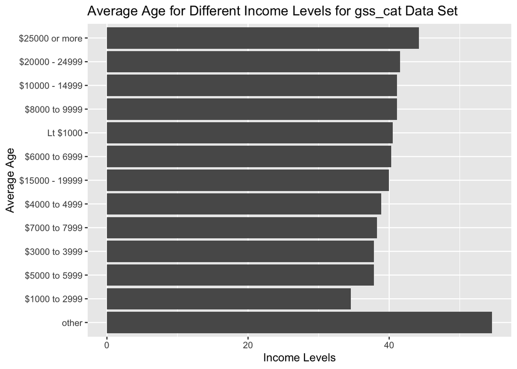

```r
gss_cat %>%
  drop_na(age) %>%
  mutate(rincome = fct_recode(rincome,
    "other" = "No answer",
    "other" = "Don't know",
    "other" = "Refused",
    "other" = "Not applicable",
  )) %>%
  group_by(rincome) %>%
  summarize(avg = mean(age)) %>%
  ggplot(aes(x = avg, y = rincome %>% fct_reorder(avg) %>% fct_relevel("other", after = 0))) +
    geom_col() +
    labs(
      x = "Income Levels",
      y = "Average Age",
      title = "Average Age for Different Income Levels for gss_cat Data Set"
    )
```